# Data Science Capstone – Text Predictive Model

# 1 Introduction

In this project, we are going to develop a text typing helper app which tries to predict and pop-up what user will type next. The model will be trained by data collected in various twitter sites, blogs and news website. We first perform some exploratory analysis here before continue to develop the predictive model.

# 2 Libraries

Here are the libraries we needed.

```r
library(dplyr)
library(tidyr)
library(knitr)
library(ggplot2)
library(ggrepel)
library(tm)
library(wordcloud)
options(digits = 9)
```

# 3 Splitting Data

First, we need to partition the data into training and validation set. Since the data size is very big, it is sufficient to set the test size to validation size to 99:1. In that way, we can have the model developed by the training set to be more robust. We define **partitionTextFile** function below to perform the task:

```r
partitionTextFile <- function(file.name, validation.p = 0.01){

  con <- file(file.name, "r")
  x <- readLines(con)
  close(con)

  valid.pos <- sample(1:length(x), size =
      round(length(x) * validation.p, 0))

  train_set <- x[-valid.pos]
  valid_set <- x[valid.pos]

  train_file_name <- gsub('.txt', '_train.txt', file.name)
  valid_file_name <- gsub('.txt', '_valid.txt', file.name)

  write(x = train_set, file = train_file_name)
  write(x = valid_set, file = valid_file_name)
}

#Applying the function
set.seed(12345)
file.names <- paste(base_wd, c('en_US.news.txt', 'en_US.blogs.txt', 'en_US.twitter.txt'), sep = "")
for(i in 1:length(file.names)){
  partitionTextFile(file.name = file.names[i], 0.01)
}
```

# 4 Map-Reduce System to Tokenize the data

There is a special phase that I used python mapper and reducer framework to tokenize the data. The whole system performs the following tasks:

1. Convert all alphabetic characters to lower case
2. Substituting all the non-alphabetic characters (except “’”) to space
3. Split the string by space into tokens
4. In each tokens, insert a special token “s1” before the start of a sentence or “e1” after the end of a sentence
5. Reducer – Aggregation:
1. Mono-gram: Sort, group and count the tokens
2. Bi-gram: Sort, group tokens in pairs and count the pairs occurrence

# 5 Clean up of tokens

After the basic tokenize functions, we perform last step that replacing the “’” except the words involved in contraction see https://en.wikipedia.org/wiki/Contraction_(grammar). The function is defined as below:

Note that **twitter_unigrams_df** and **twitter_bigrams_df** are our monogram and bigram input.

```r
cleaningQuote <- function(my_df, col.names){

# Replace the "'" characters except the contractions
# contractions: "n't" , "'s", "i'm", "'ve", "'d", "'ll", "o'"

  for(i in 1:length(col.names)){

    dummy_str <- as.vector(my_df[[col.names[i]]])

    contraction_flag1 <- grepl("^.*(n\\'t)$", dummy_str)
    contraction_flag2 <- grepl("^.*(\\'s)$", dummy_str)
    contraction_flag3 <- grepl("^i\\'m$", dummy_str)
    contraction_flag4 <- grepl("^.*(\\'ve)$", dummy_str)
    contraction_flag5 <- grepl("^.*(\\'d)$", dummy_str)
    contraction_flag6 <- grepl("^.*(\\'ll)$", dummy_str)
    contraction_flag7 <- grepl("^(o\\').*$", dummy_str)

    contraction_flags <- contraction_flag1 | contraction_flag2 | contraction_flag3 |
      contraction_flag4 | contraction_flag5 | contraction_flag6 | contraction_flag7

    dummy_str[!contraction_flags] <- gsub("'", "", x = dummy_str[!contraction_flags])

    #Replace <s1> by s1 and <e1> by e1 because of the html problem etc.
    dummy_str <- gsub('<s>', 's1', dummy_str)
    dummy_str <- gsub('<e>', 'e1', dummy_str)
    dummy_str <- gsub('<|>', '', dummy_str)

    my_df[, names(my_df) == col.names[i]] <- dummy_str

  }

  return(my_df)
}
```

Now, let’s apply this function to clean up the quotes and data frame the tokens tables.

```r
#blogs
blogs_unigrams_df        <- read.table(paste(base_wd, 'blogs_uni_tokens_train_py.txt', sep =""),
  sep = "\t", header = F,  quote = "\"",  stringsAsFactors = FALSE)
names(blogs_unigrams_df) <- c('Token', 'cnt')

blogs_unigrams_df <- cleaningQuote(blogs_unigrams_df, col.names = 'Token')
blogs_unigrams_df <- blogs_unigrams_df %>% group_by(Token) %>% summarise(cnt = sum(cnt)) %>% ungroup()
blogs_unigrams_df <- blogs_unigrams_df %>% arrange(desc(cnt))

blogs_bigrams_df        <- read.table(paste(base_wd, 'blogs_bi_tokens_train_py.txt', sep =""),
  sep = "\t", header = F,  quote = "\"",  stringsAsFactors = FALSE)
names(blogs_bigrams_df) <- c('Token1', 'Token2', 'cnt')

blogs_bigrams_df <- cleaningQuote(blogs_bigrams_df, col.names = c('Token1', 'Token2'))
blogs_bigrams_df <- blogs_bigrams_df %>% group_by(Token1, Token2) %>% summarise(cnt = sum(cnt)) %>% ungroup()
blogs_bigrams_df <- blogs_bigrams_df %>% arrange(desc(cnt))


#twitter
twitter_unigrams_df        <- read.table(paste(base_wd, 'twitter_uni_tokens_train_py.txt', sep =""),
  sep = "\t", header = F,  quote = "\"",  stringsAsFactors = FALSE)
names(twitter_unigrams_df) <- c('Token', 'cnt')

twitter_unigrams_df <- cleaningQuote(twitter_unigrams_df, col.names = 'Token')
twitter_unigrams_df <- twitter_unigrams_df %>% group_by(Token) %>% summarise(cnt = sum(cnt)) %>% ungroup()
twitter_unigrams_df <- twitter_unigrams_df %>% arrange(desc(cnt))

twitter_bigrams_df        <- read.table(paste(base_wd, 'twitter_bi_tokens_train_py.txt', sep =""),
  sep = "\t", header = F,  quote = "\"",  stringsAsFactors = FALSE)
names(twitter_bigrams_df) <- c('Token1', 'Token2', 'cnt')

twitter_bigrams_df <- cleaningQuote(twitter_bigrams_df, col.names = c('Token1', 'Token2'))
twitter_bigrams_df <- twitter_bigrams_df %>% group_by(Token1, Token2) %>% summarise(cnt = sum(cnt)) %>% ungroup()
twitter_bigrams_df <- twitter_bigrams_df %>% arrange(desc(cnt))

#news
news_unigrams_df        <- read.table(paste(base_wd, 'news_uni_tokens_train_py.txt', sep =""),
  sep = "\t", header = F,  quote = "\"",  stringsAsFactors = FALSE)
names(news_unigrams_df) <- c('Token', 'cnt')

news_unigrams_df <- cleaningQuote(news_unigrams_df, col.names = 'Token')
news_unigrams_df <- news_unigrams_df %>% group_by(Token) %>% summarise(cnt = sum(cnt)) %>% ungroup()
news_unigrams_df <- news_unigrams_df %>% arrange(desc(cnt))

news_bigrams_df        <- read.table(paste(base_wd, 'news_bi_tokens_train_py.txt', sep =""),
  sep = "\t", header = F,  quote = "\"",  stringsAsFactors = FALSE)
names(news_bigrams_df) <- c('Token1', 'Token2', 'cnt')

news_bigrams_df <- cleaningQuote(news_bigrams_df, col.names = c('Token1', 'Token2'))
news_bigrams_df <- news_bigrams_df %>% group_by(Token1, Token2) %>% summarise(cnt = sum(cnt)) %>% ungroup()
news_bigrams_df <- news_bigrams_df %>% arrange(desc(cnt))


#Save as .csv files
write.csv(blogs_unigrams_df, paste(base_wd, 'blogs_uni_tokens_train_py.csv', sep =""), row.names = F)
write.csv(blogs_bigrams_df, paste(base_wd, 'blogs_bi_tokens_train_py.csv', sep =""), row.names = F)

write.csv(twitter_unigrams_df, paste(base_wd, 'twitter_uni_tokens_train_py.csv', sep =""), row.names = F)
write.csv(twitter_bigrams_df, paste(base_wd, 'twitter_bi_tokens_train_py.csv', sep =""), row.names = F)

write.csv(news_unigrams_df, paste(base_wd, 'news_uni_tokens_train_py.csv', sep =""), row.names = F)
write.csv(news_bigrams_df, paste(base_wd, 'news_bi_tokens_train_py.csv', sep =""), row.names = F)

#Save as .RData
save(blogs_unigrams_df, blogs_bigrams_df,
  twitter_unigrams_df, twitter_bigrams_df,
  news_unigrams_df, news_bigrams_df, file = paste(base_wd, 'tokens_df.RData', sep =""))
```

Let’s take a look on the first few elements of the twitter uni-gram and bi-gram data frame.

| Token | cnt |
| --- | --- |
| s1 | 4,039,191 |
| e1 | 4,028,292 |
| the | 928,510 |
| to | 780,904 |
| i | 720,698 |
| a | 610,760 |
| you | 544,098 |
| and | 434,252 |
| for | 381,607 |
| in | 376,915 |

| Token1 | Token2 | cnt |
| --- | --- | --- |
| s1 | i | 331,304 |
| in | the | 77,611 |
| for | the | 73,205 |
| s1 | thanks | 71,240 |
| it | e1 | 70,747 |
| you | e1 | 67,896 |
| s1 | the | 67,109 |
| s1 | you | 66,959 |
| s1 | i’m | 64,803 |
| s1 | rt | 63,419 |

Although s1 and e1 are not exactly paired up, their numbers are closed enough to proceed.

# 6 Dictionary & Stop Words Check

Let’s check how many of them are English words from a standard dictionary. We grab this from a simple dictionary online from https://github.com/dwyl/English-words with 350 thousands words plus. Note that, it doesn’t contain complicated words so it only serves for a proxy for us to compare our three difference source ( **twitter**, **news**, **blogs** ).

Also, a lot of common words such as “I’m”, “We”, “there”, “the” etc. don’t tell any thing about the articles. In view of that, we filter a list of “stop words” from the **tm** package.

To enhance flexibility, we flag those tokens here rather than a direct filtering.

```r
#loading dictionary by line
con <- file(paste(base_wd, "simple_words.txt", sep = ""), "r")
my_dictionary <- readLines(con)
close(con)

stopwords <- tm::stopwords()

flagTokens <- function(my_df, col.names, dictionary, stopwords){

  for(i in 1:length(col.names)){

     dummy_str <- as.vector(my_df[[col.names[i]]])
     Eng_Word_new  <- dummy_str %in% dictionary | grepl("^(.)*'", x = dummy_str)
     Stop_Word_new <- dummy_str %in% stopwords

     if(i > 1){

       Eng_Word  <- Eng_Word  | Eng_Word_new
       Stop_Word <- Stop_Word | Stop_Word_new

     }else{

       Eng_Word  <- Eng_Word_new
       Stop_Word <- Stop_Word_new

     }

  }

  my_df$Eng_Word <- Eng_Word
  my_df$Stop_Word <- Stop_Word

  return(my_df)
}

blogs_unigrams_df <- flagTokens(blogs_unigrams_df, col.names = c('Token'),
  dictionary = my_dictionary, stopwords = stopwords)

blogs_bigrams_df <- flagTokens(blogs_bigrams_df, col.names = c('Token1', 'Token2'),
  dictionary = my_dictionary, stopwords = stopwords)


twitter_unigrams_df <- flagTokens(twitter_unigrams_df, col.names = c('Token'),
  dictionary = my_dictionary, stopwords = stopwords)

twitter_bigrams_df <- flagTokens(twitter_bigrams_df, col.names = c('Token1', 'Token2'),
  dictionary = my_dictionary, stopwords = stopwords)

news_unigrams_df <- flagTokens(news_unigrams_df, col.names = c('Token'),
  dictionary = my_dictionary, stopwords = stopwords)

news_bigrams_df <- flagTokens(news_bigrams_df, col.names = c('Token1', 'Token2'),
  dictionary = my_dictionary, stopwords = stopwords)


#Save as .RData
save(blogs_unigrams_df, blogs_bigrams_df,
  twitter_unigrams_df, twitter_bigrams_df,
  news_unigrams_df, news_bigrams_df, file = paste(base_wd, 'ngrams_df.RData', sep =""))
```

# 7 Basic Statistics

Now, let’s explore some basic statistics in those three different training set.

```r
file_name <- paste(base_wd, "en_US.blogs_train.txt", sep = "")
con <- file(file_name, "r")
train_set <- readLines(con)
close(con)
blogs_num_of_lines <- length(train_set)
blogs_file_size    <- paste(round(file.info(file_name)$size / 1024^2, 2), "MB")
rm(train_set)

file_name <- paste(base_wd, "en_US.twitter_train.txt", sep = "")
con <- file(file_name, "r")
train_set <- readLines(con)
close(con)
twitter_num_of_lines   <- length(train_set)
twitter_file_size      <- paste(round(file.info(file_name)$size / 1024^2, 2), "MB")
rm(train_set)

file_name <- paste(base_wd, "en_US.news_train.txt", sep = "")
con <- file(file_name, "r")
train_set <- readLines(con)
close(con)
news_num_of_lines <- length(train_set)
news_file_size    <- paste(round(file.info(file_name)$size / 1024^2, 2), "MB")
rm(train_set)

basic_stat <- data.frame(source = c('Blogs', 'Twitter', 'News'))
basic_stat$`File Size` <- c(blogs_file_size, twitter_file_size, news_file_size)
basic_stat$Paragraphs <- c(blogs_num_of_lines, twitter_num_of_lines, news_num_of_lines)
basic_stat$Sentences <- c(
  sum(blogs_unigrams_df$cnt[blogs_unigrams_df$Token != 'e1']),
  sum(twitter_unigrams_df$cnt[twitter_unigrams_df$Token != 'e1']),
  sum(news_unigrams_df$cnt[news_unigrams_df$Token != 'e1']))
basic_stat$Tokens <- c(
  sum(blogs_unigrams_df$cnt[blogs_unigrams_df$Token != 's1' & blogs_unigrams_df$Token != 'e1']),
  sum(twitter_unigrams_df$cnt[twitter_unigrams_df$Token != 's1' & twitter_unigrams_df$Token != 'e1']),
  sum(news_unigrams_df$cnt[news_unigrams_df$Token != 's1' & news_unigrams_df$Token != 'e1']))

basic_stat$`Sentence/Paragraphs` <-  round(basic_stat$Sentence/basic_stat$Paragraphs, 2)
basic_stat$`Tokens/Sentence`     <-  round(basic_stat$Tokens/basic_stat$Sentences, 2)
basic_stat$`Stop Words` <- c(
  sum(blogs_unigrams_df$cnt[blogs_unigrams_df$Stop_Word]),
  sum(twitter_unigrams_df$cnt[twitter_unigrams_df$Stop_Word]),
  sum(news_unigrams_df$cnt[news_unigrams_df$Stop_Word]))

basic_stat$`English Words` <- c(
  sum(blogs_unigrams_df$cnt[blogs_unigrams_df$Eng_Word & !blogs_unigrams_df$Stop_Word &
      blogs_unigrams_df$Token != 's1' & blogs_unigrams_df$Token != 'e1']),
  sum(twitter_unigrams_df$cnt[twitter_unigrams_df$Eng_Word & !twitter_unigrams_df$Stop_Word &
      twitter_unigrams_df$Token != 's1' & twitter_unigrams_df$Token != 'e1']),
  sum(news_unigrams_df$cnt[news_unigrams_df$Eng_Word & !news_unigrams_df$Stop_Word &
      news_unigrams_df$Token != 's1' & news_unigrams_df$Token != 'e1']))

basic_stat$`English Words %` <- round(basic_stat$`English Words`/(basic_stat$Tokens - basic_stat$`Stop Words`), 2)
```

```r
kable(basic_stat, format.args = list(big.mark = ','))
```

[output not shown]

# 8 Word Cloud

Let’s explore the word cloud of each source.

## 8.1 Blogs

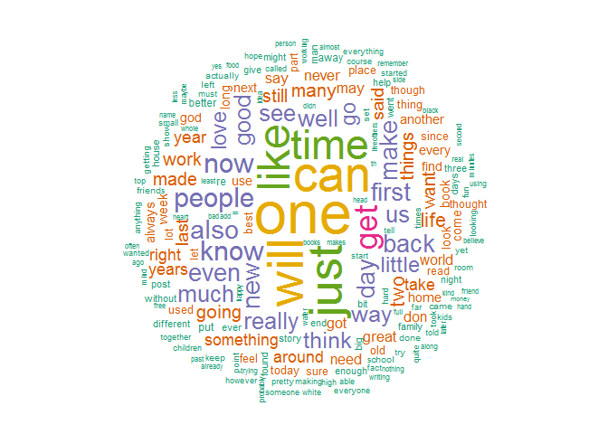

## 8.2 Twitter

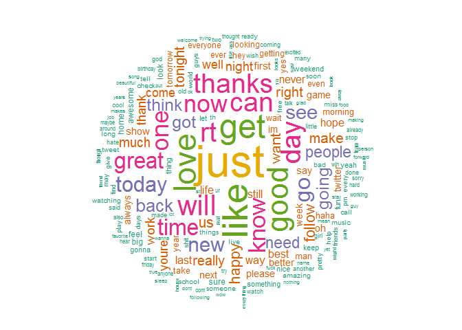

## 8.3 News

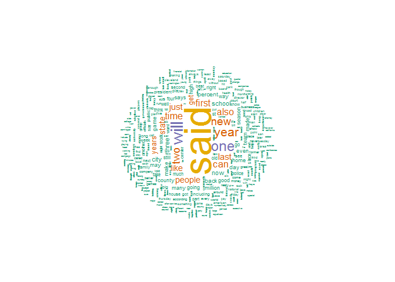

Interestingly, **twitter** and **blogs** are very similar with words such as “like”, “time”, “love”, “thanks”, “one” etc. **twitter** also has its own popular words such as “haha” and “rt” (retweet). On the other hand, in **news**, a very significantly dominating word is “said”.

# 9 Histogram of 2-Gram Terms

## 9.1 Blogs

Let’s also explore the 2-gram level terms. “New York”, “right now”“,”years ago" are the most frequent terms in **blogs**. “Right now” and “last night” are the most frequent terms in **twitter**. “New York”, “years old” and “last year” are the most frequent terms in **news**,

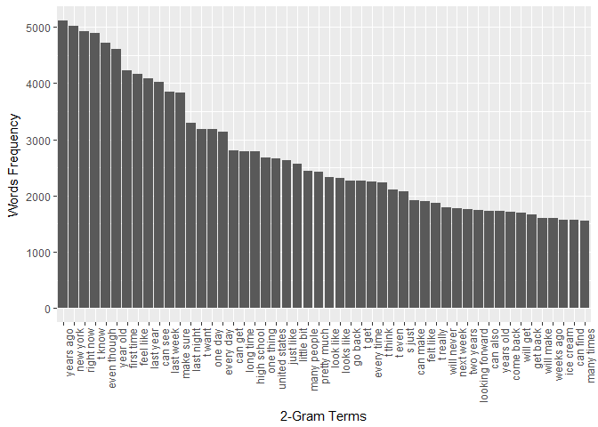

## 9.2 Twitter

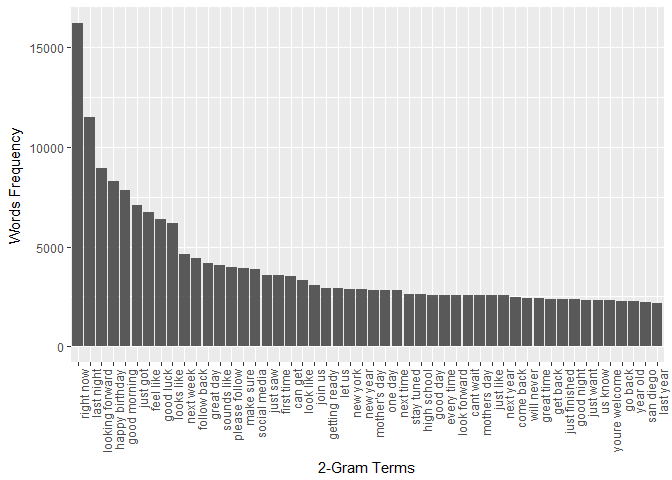

## 9.3 News

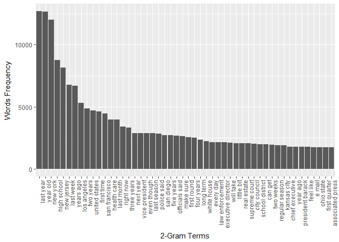